# Human Activity Recognition Model

## Executive Summary

In this report I will deal with data from accelerometers of 6 participants, and develop a model to predict activity quality by using machine learning algorithms in CARET Package of R programming language. These models will be used to predict outcome of the new data

First, let’s set global options and load necessary libraries.

```r
# knitr configuration
library(knitr)
opts_knit$set(progress=FALSE)
opts_chunk$set(echo=TRUE, message=FALSE, tidy=TRUE, comment=NA,
               fig.path="figure/", fig.keep="high", fig.width=10, fig.height=6)
# load required libs
library(caret, quietly=TRUE, warn.conflicts=FALSE)
library(lattice, quietly=TRUE, warn.conflicts=FALSE)
library(randomForest, quietly=TRUE, warn.conflicts=FALSE)
```

## Data Processing

Loading and preprocessing the data.

```r
if (!file.exists("pml-training.csv")) {
    fileurl <- "https://d396qusza40orc.cloudfront.net/predmachlearn/pml-training.csv"
    download.file(fileurl, destfile = "./pml-training.csv")
}
if (!file.exists("pml-testing.csv")) {
    fileurl <- "https://d396qusza40orc.cloudfront.net/predmachlearn/pml-testing.csv"
    download.file(fileurl, destfile = "./pml-testing.csv")
}
dataTraining <- read.csv("./pml-training.csv", na.strings = c("NA", "", " "))
```

There are a lot of variables full of NA values that only introduce noise. So I subset the dataset and only choose 52 variables as predictors. Moreover, the first 7 columns that contain metadata not pertinent to the prediction model are also removed.

```r
# clean the data by removing columns with NAs
dataTraining_val <- colSums(is.na(dataTraining)) == 0
# 52 features are selected as predictors
features <- colnames(dataTraining[dataTraining_val])[8:59]
trainingData <- dataTraining[, c(features, "classe")]
```

## Data partitioning

The training data set is split up into training and cross validation sets in a 70:30 ratio for building the model and be ready for cross validation.

```r
set.seed(2046)
inTrain = createDataPartition(trainingData$classe, p = 0.7, list = F)
training = trainingData[inTrain, ]
validating = trainingData[-inTrain, ]
```

## Model building

First, let’s analyze the correlation between features to see how strong the variables relationships are with each other. As we can see from the plot below,there is not much concern for highly correlated predictors, so we can include all of them in the model.

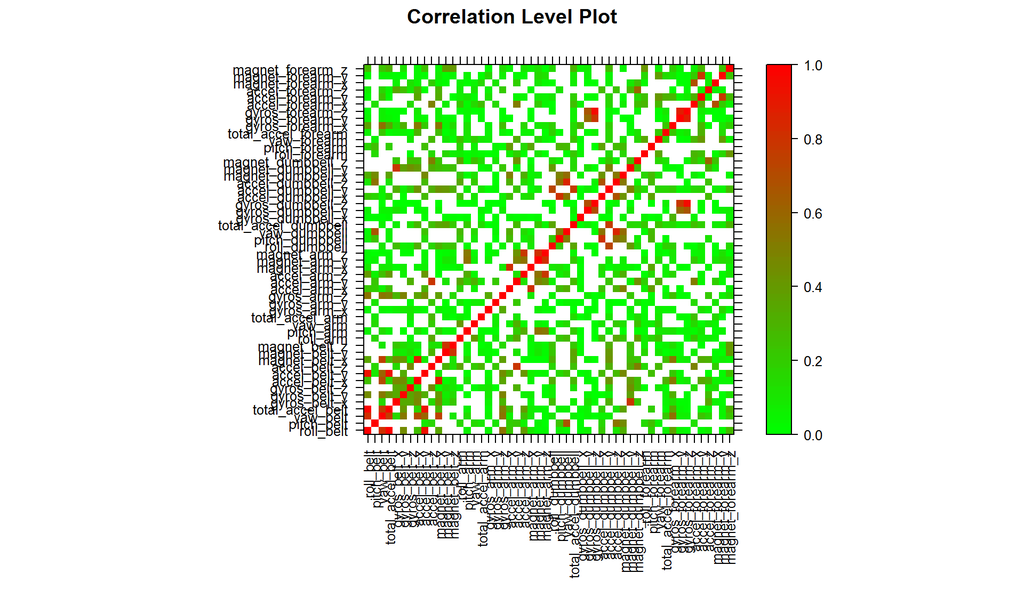

```r
# plot a correlation matrix
correlation <- cor(training[, -length(training)])
palette <- colorRampPalette(c("green", "red"), space = "rgb")
levelplot(correlation, main = "Correlation Level Plot", xlab = "", ylab = "",
    aspect = 1, col.regions = palette(120), pretty = TRUE, cuts = 100, at = seq(0,
        1, 0.01), scales = list(x = list(rot = 90)))
```

After a preliminary analysis (not reported here), I choose to run a Random Forest model for that it works well on the data set. Random forest model runtime is quite fast, and it is able to deal with unbalanced and missing data.

```r
model <- randomForest(classe ~ ., data = training, importance = TRUE)
model
```

```
Call:
 randomForest(formula = classe ~ ., data = training, importance = TRUE)
               Type of random forest: classification
                     Number of trees: 500
No. of variables tried at each split: 7

        OOB estimate of  error rate: 0.5%
Confusion matrix:
     A    B    C    D    E class.error
A 3902    3    0    0    1 0.001024066
B   10 2642    6    0    0 0.006019564
C    0   11 2383    2    0 0.005425710
D    0    0   27 2223    2 0.012877442
E    0    0    3    3 2519 0.002376238
```

The model seems to fit very well. The out-of-bag (OOB) error estimate is 0.5%, and it can be deemed satisfactory enough to progress the testing.

## Cross validation

```r
# in sample accuracy
confusionMatrix(training$classe, model$predicted)
```

```
Confusion Matrix and Statistics

          Reference
Prediction    A    B    C    D    E
         A 3902    3    0    0    1
         B   10 2642    6    0    0
         C    0   11 2383    2    0
         D    0    0   27 2223    2
         E    0    0    3    3 2519

Overall Statistics

               Accuracy : 0.995
                 95% CI : (0.9937, 0.9962)
    No Information Rate : 0.2848
    P-Value [Acc > NIR] : < 2.2e-16

                  Kappa : 0.9937
 Mcnemar's Test P-Value : NA

Statistics by Class:

                     Class: A Class: B Class: C Class: D Class: E
Sensitivity            0.9974   0.9947   0.9851   0.9978   0.9988
Specificity            0.9996   0.9986   0.9989   0.9975   0.9995
Pos Pred Value         0.9990   0.9940   0.9946   0.9871   0.9976
Neg Pred Value         0.9990   0.9987   0.9968   0.9996   0.9997
Prevalence             0.2848   0.1933   0.1761   0.1622   0.1836
Detection Rate         0.2841   0.1923   0.1735   0.1618   0.1834
Detection Prevalence   0.2843   0.1935   0.1744   0.1639   0.1838
Balanced Accuracy      0.9985   0.9966   0.9920   0.9976   0.9991
```

```r
# out of sample error to be estimated
CrossVal <- predict(model, validating)
confusionMatrix(validating$classe, CrossVal)
```

```
Confusion Matrix and Statistics

          Reference
Prediction    A    B    C    D    E
         A 1674    0    0    0    0
         B    4 1129    6    0    0
         C    0    7 1018    1    0
         D    0    0   11  953    0
         E    0    0    3    0 1079

Overall Statistics

               Accuracy : 0.9946
                 95% CI : (0.9923, 0.9963)
    No Information Rate : 0.2851
    P-Value [Acc > NIR] : < 2.2e-16

                  Kappa : 0.9931
 Mcnemar's Test P-Value : NA

Statistics by Class:

                     Class: A Class: B Class: C Class: D Class: E
Sensitivity            0.9976   0.9938   0.9807   0.9990   1.0000
Specificity            1.0000   0.9979   0.9983   0.9978   0.9994
Pos Pred Value         1.0000   0.9912   0.9922   0.9886   0.9972
Neg Pred Value         0.9991   0.9985   0.9959   0.9998   1.0000
Prevalence             0.2851   0.1930   0.1764   0.1621   0.1833
Detection Rate         0.2845   0.1918   0.1730   0.1619   0.1833
Detection Prevalence   0.2845   0.1935   0.1743   0.1638   0.1839
Balanced Accuracy      0.9988   0.9959   0.9895   0.9984   0.9997
```

Both accuracies are over 99%. The model well fit the prediction.

## Prediction

Here, I apply the model built above, to the testing dataset provided.

```r
# apply the same treatment to the testing data
dataTesting <- read.csv("./pml-testing.csv", na.strings = c("NA", "", " "))
dataTesting_val <- colSums(is.na(dataTesting)) == 0
features <- colnames(dataTesting[dataTesting_val])[8:59]
testingData <- dataTesting[, c(features, "problem_id")]

# predict the classes of the test set
testPredict <- predict(model, testingData)
testPredict
```

```
 1  2  3  4  5  6  7  8  9 10 11 12 13 14 15 16 17 18 19 20
 B  A  B  A  A  E  D  B  A  A  B  C  B  A  E  E  A  B  B  B
Levels: A B C D E
```